# Exploration of Prosper Loan Data, by Max Sydow

> Prosper Loans is a private personal loan issuer. The overall data set has 82 variables, but here we will look at 18 of them. They are as follows:

```r
str(loan)
```

```
## 'data.frame':    113937 obs. of  18 variables:
##  $ Term                    : int  36 36 36 36 36 60 36 36 36 36 ...
##  $ LoanStatus              : Factor w/ 12 levels "Cancelled","Chargedoff",..: 3 4 3 4 4 4 4 4 4 4 ...
##  $ BorrowerRate            : num  0.158 0.092 0.275 0.0974 0.2085 ...
##  $ BorrowerAPR             : num  0.165 0.12 0.283 0.125 0.246 ...
##  $ ProsperScore            : int  NA 7 NA 9 4 10 2 4 9 11 ...
##  $ BorrowerState           : Factor w/ 52 levels "","AK","AL","AR",..: 7 7 12 12 25 34 18 6 16 16 ...
##  $ EmploymentStatus        : Factor w/ 9 levels "","Employed",..: 9 2 4 2 2 2 2 2 2 2 ...
##  $ EmploymentStatusDuration: int  2 44 NA 113 44 82 172 103 269 269 ...
##  $ IncomeRange             : Factor w/ 8 levels "$0 ","$1-24,999",..: 4 5 7 4 3 3 4 4 4 4 ...
##  $ LoanOriginalAmount      : int  9425 10000 3001 10000 15000 15000 3000 10000 10000 10000 ...
##  $ DebtToIncomeRatio       : num  0.17 0.18 0.06 0.15 0.26 0.36 0.27 0.24 0.25 0.25 ...
##  $ IncomeVerifiable        : logi  TRUE TRUE TRUE TRUE TRUE TRUE ...
##  $ TotalProsperLoans       : int  NA NA NA NA 1 NA NA NA NA NA ...
##  $ Investors               : int  258 1 41 158 20 1 1 1 1 1 ...
##  $ Occupation              : Factor w/ 68 levels "","Accountant/CPA",..: 37 43 37 52 21 43 50 29 24 24 ...
##  $ CreditScoreRangeLower   : int  640 680 480 800 680 740 680 700 820 820 ...
##  $ CreditScoreRangeUpper   : int  659 699 499 819 699 759 699 719 839 839 ...
##  $ ListingCategory         : int  0 2 0 16 2 1 1 2 7 7 ...
```

> The data can be found at https://s3.amazonaws.com/udacity-hosted-downloads/ud651/prosperLoanData.csv. A description of each variable is included in this link: https://docs.google.com/spreadsheets/d/1gDyi_L4UvIrLTEC6Wri5nbaMmkGmLQBk-Yx3z0XDEtI/edit#gid=0.

# Univariate Plots Section

### Loan Term Lengths

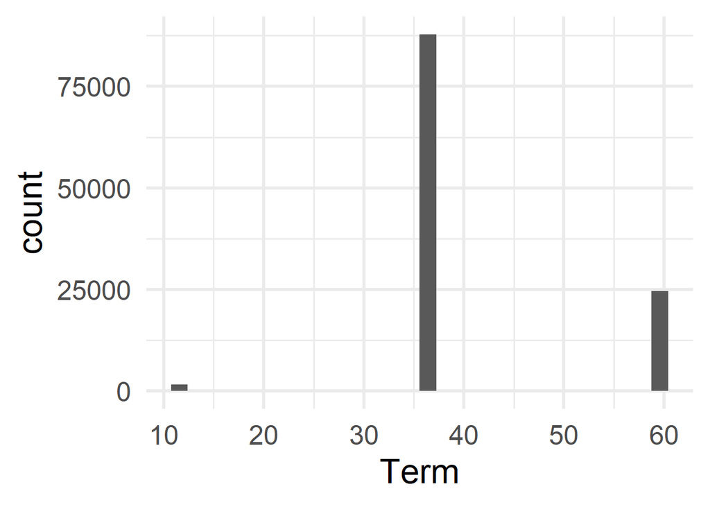

```
##    Min. 1st Qu.  Median    Mean 3rd Qu.    Max.
##   12.00   36.00   36.00   40.83   36.00   60.00
```

> It looks like there are only 3 lengths of loan terms. Most are for 36 months, fewer have a duration of 60, and a small number were payed off in 12 months.

### Loan Status

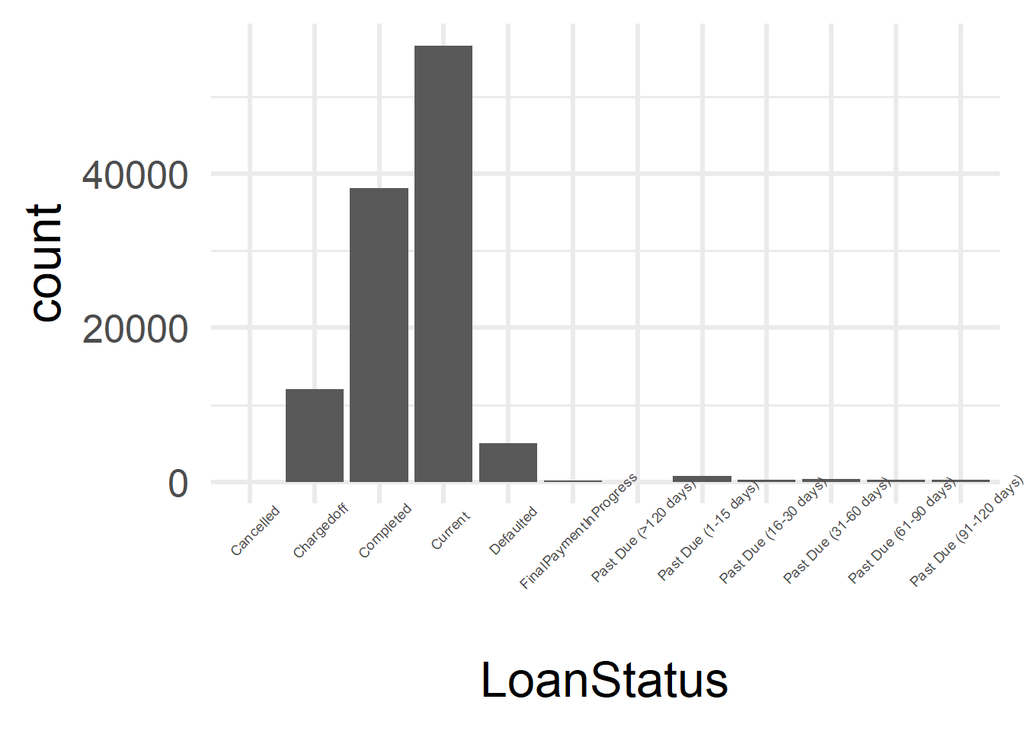

### Listing Category

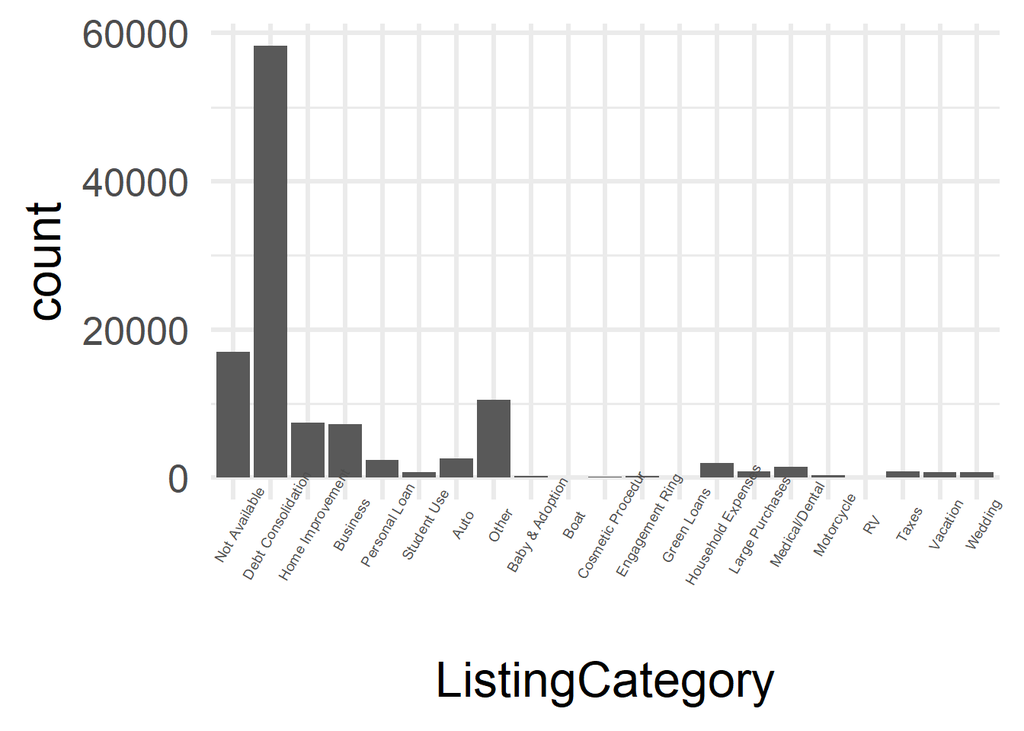

> By far most of the loans are for debt consolidation. There’s also a large portion with no description. Home improvement and business loans are relatively prevelant compared to other types.

### Borrower Rate

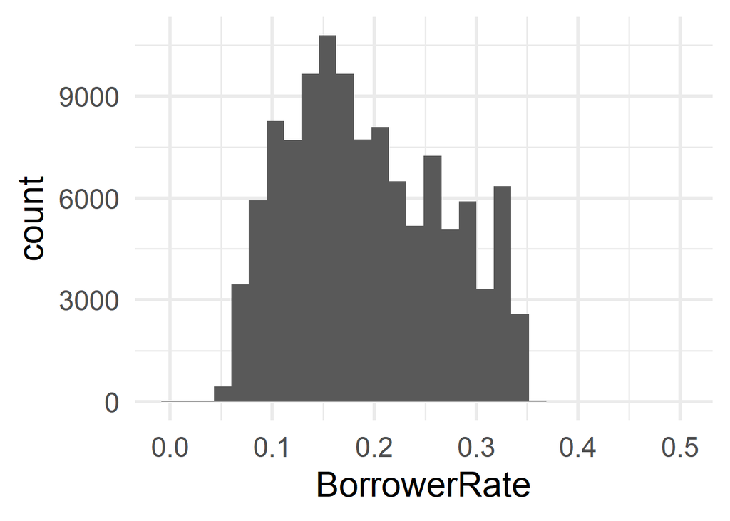

> I chose to look at Borrower Rate instead of APR for simplicity. This is just the overall total amount of interest on the loan. The distribution looks fairly normal with some rates more common than others. For example, 0.325 is far more common than 0.31.

### Borrower APR

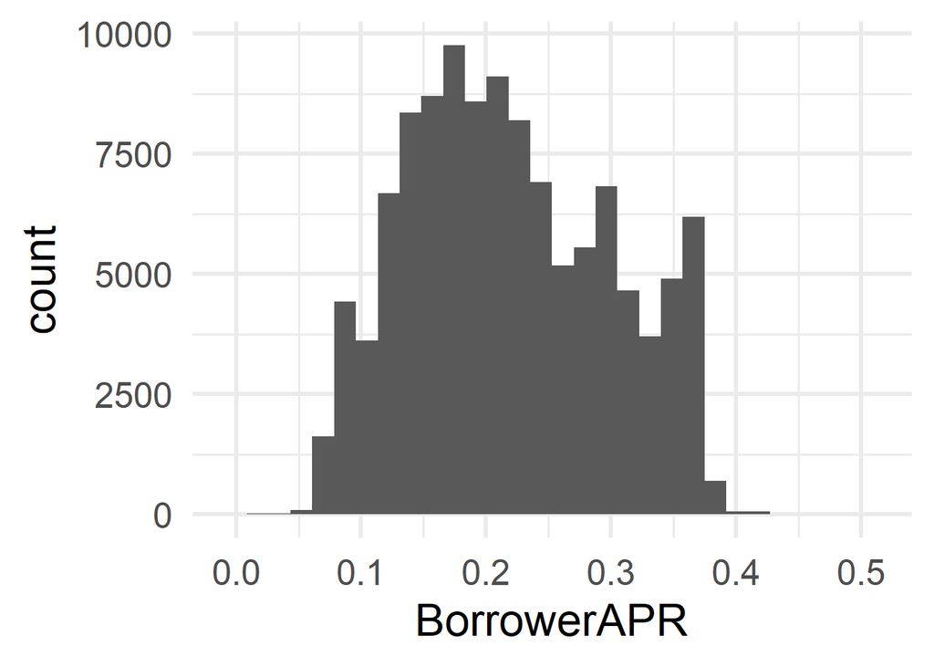

> The spikes in the Borrower Rate distribution made me want to look at APR as well, so I went back and added it to my data frame. Spikes appear here too. I’m sure there’s a reason for this, and maybe accountant for Prosper Loans could give an explanation. For now, I’ll just leave it as an interesting observation.

### Borrower State

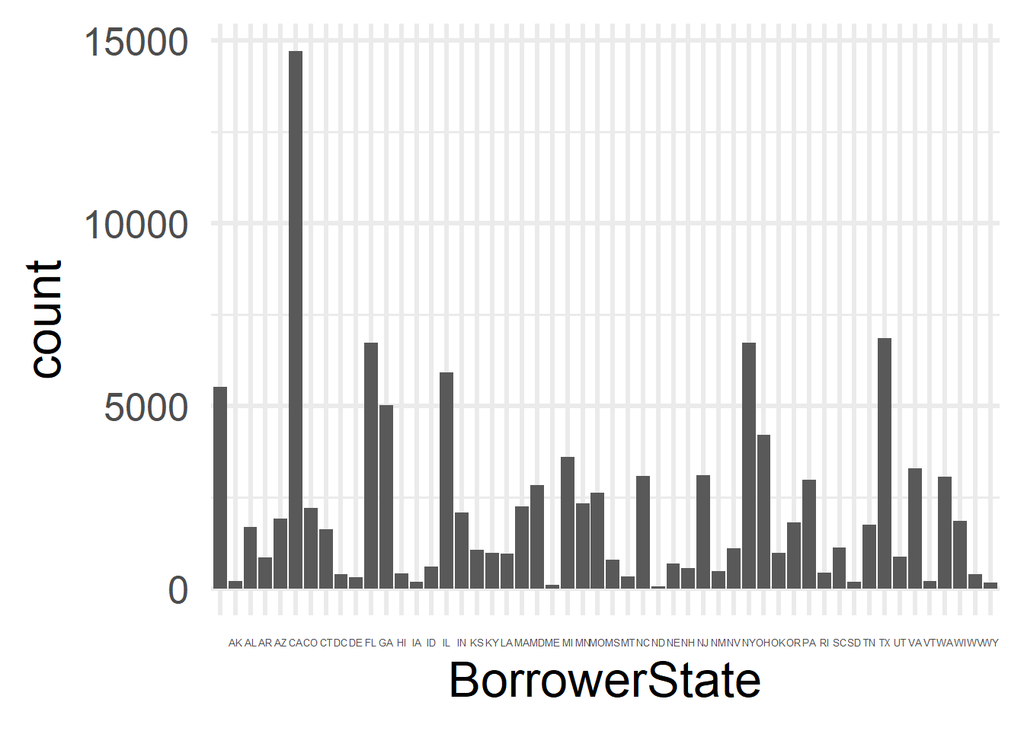

> California has the most loans. This makes sense, since it is the most populous state. It also makes sense that other populous states like New York, Texas, Florida, and Illinois have higher counts. The unlabled spike might be where state info is not available, or maybe loans from US territories. No description for that category was given in the variable definitions document.

### ProsperScore

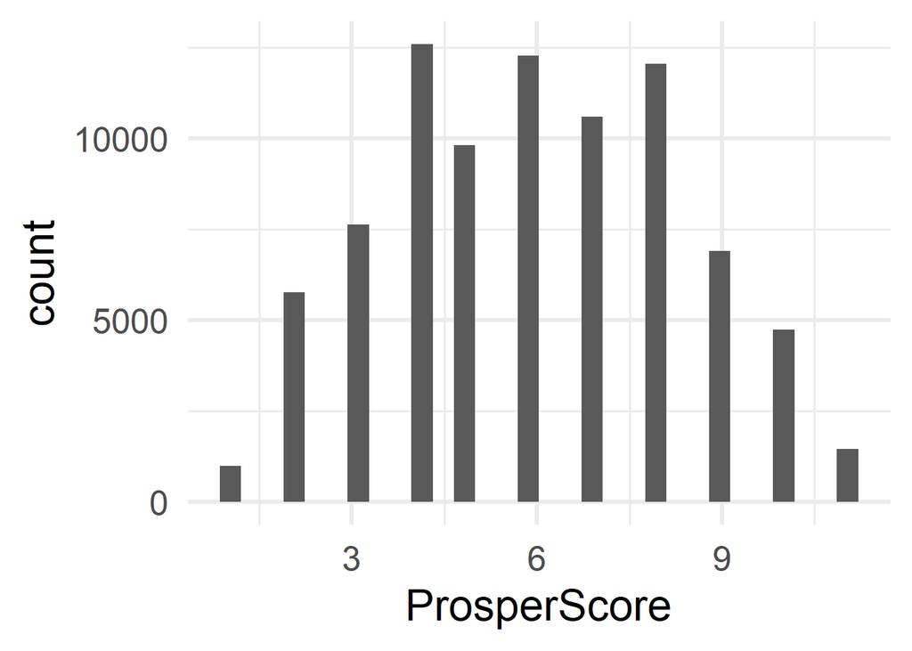

### Employment Status

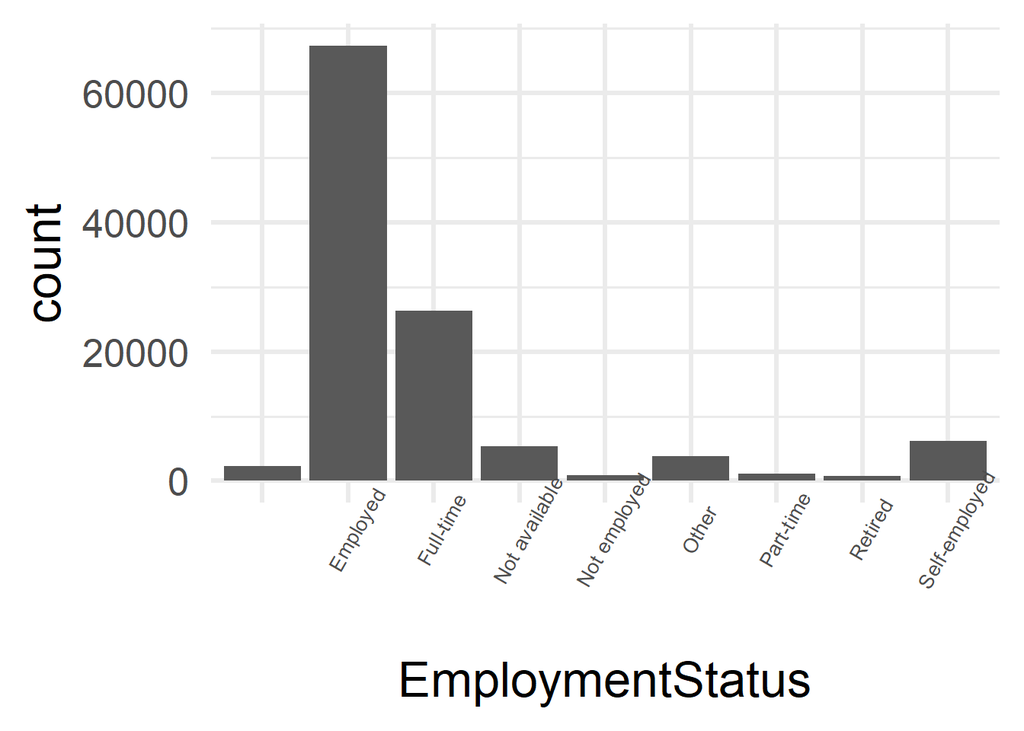

> Most loan takers are employed, or employed full-time. This seems reasonable. Another significant portion are self-employed. This seems to fit with the independent nature of Prosper Loans and may be related to the occurance of small business loans observed above.

### Employment Status Duration

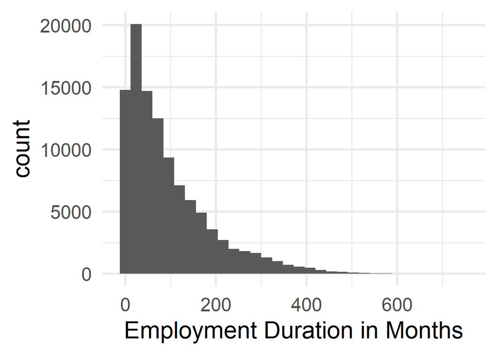

> With a bin width of 24 months it appears that a large number of loan recipients have been employed between 0 and 2 years, with a peak between 2-4 years, then trailing off for longer durations of employemnt. People who have been employed longer may have more savings and less need for loans. Those who are starting their careers may need or want some help with money for some of the categories for loans.

### Income Range

```r
levels(loan$IncomeRange)
```

```
## [1] "$0 "            "$1-24,999"      "$100,000+"      "$25,000-49,999"
## [5] "$50,000-74,999" "$75,000-99,999" "Not displayed"  "Not employed"
```

```r
loan$IncomeRange <- ordered(loan$IncomeRange, levels = c('$0', '$1-24,999', '$25,000-49,999',                                                                      '$50,000-74,999', '$75,000-99,999',                                                                        '$100,000+', 'Not employed', 'Not displayed'))
```

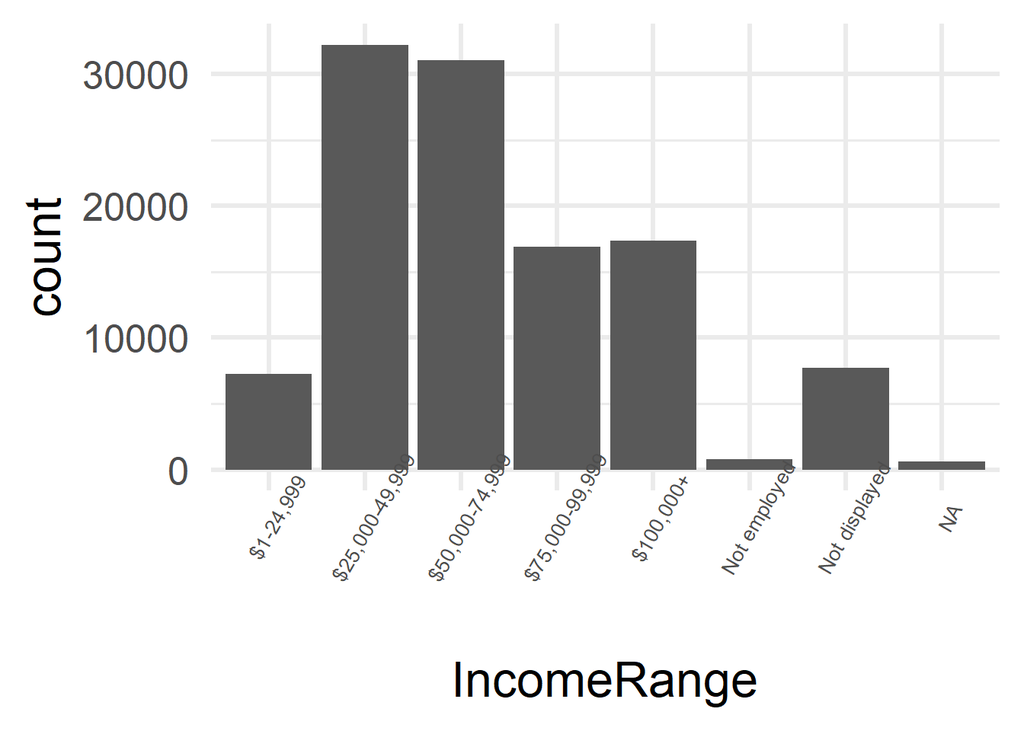

> Most loan takers are in the middle income range from $25k - $74,999k per year. Slightly more people are in the lower half of this income range. I should point out that the original array was out of order, with $100,000+ appearing between $1-24,999 and $25,000-49,999. The array was re-ordered before making the plot seen here.

### Original Loan Amount

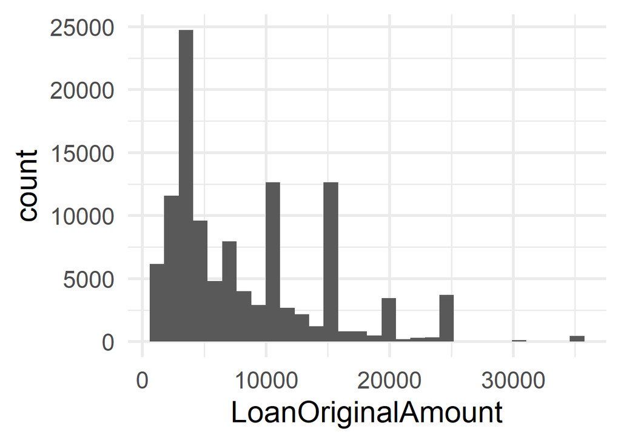

### Debt to Income Ratio

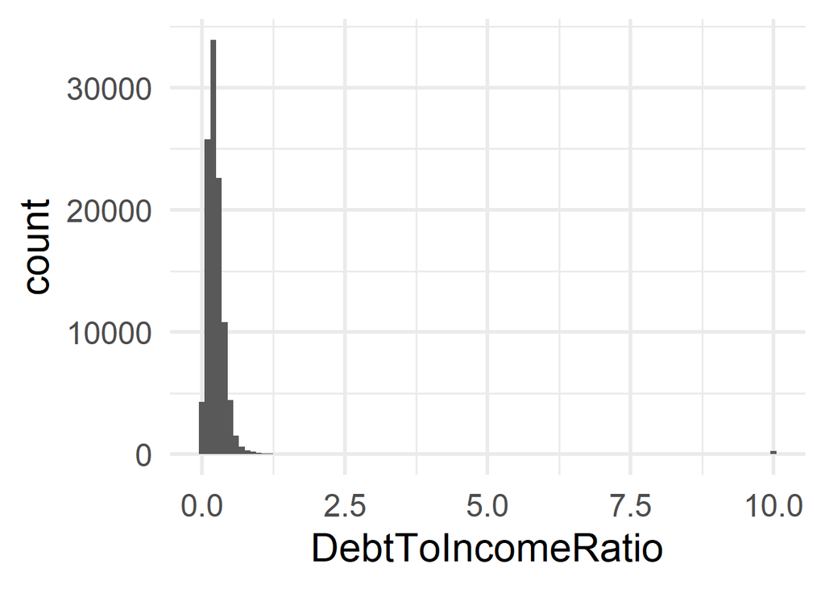

### Verifiable Income

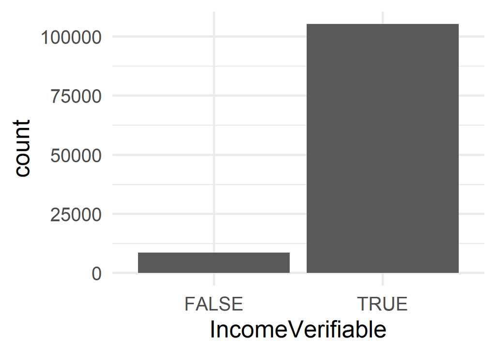

> While the majority of recipients have documentation to verify income there are a significant number who don’t. I wander what other criteria are accepted in these cases.

### Total Prosper Loans

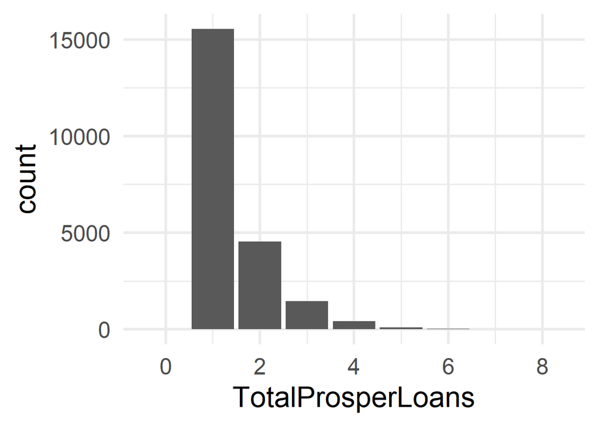

> Most people have taken only one loan, with a tapering off for subsequent loans.

### Investors

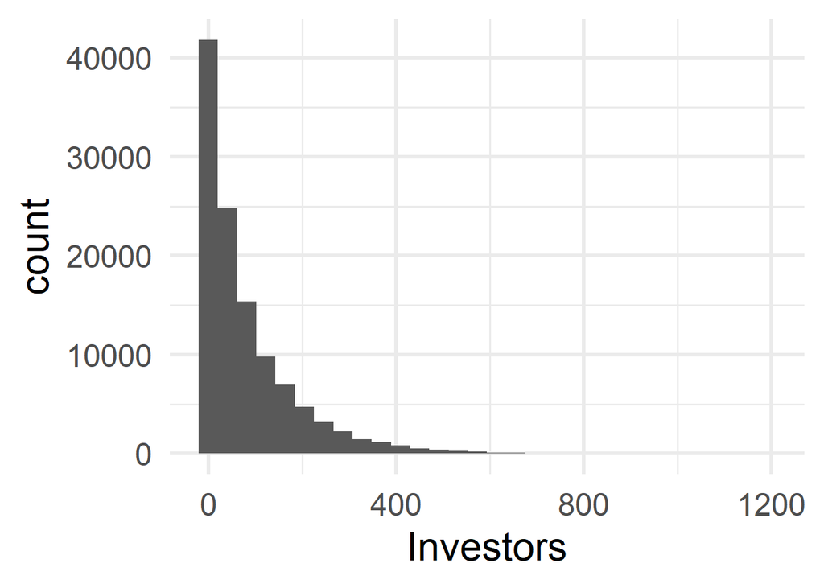

> Most loans have fewr investors, with a diminishing number having increasing number of investors.

### Occupation

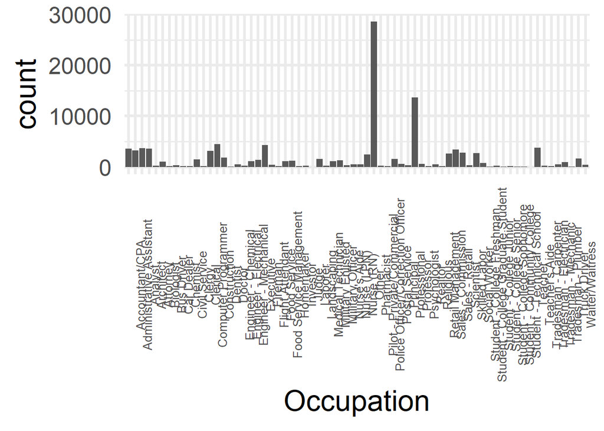

### Lower Credit Score Range

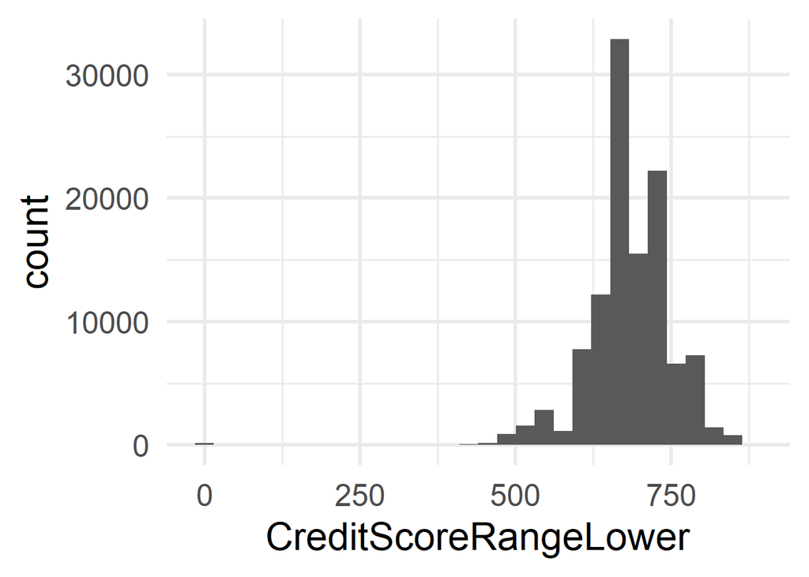

### Upper Credit Score Range

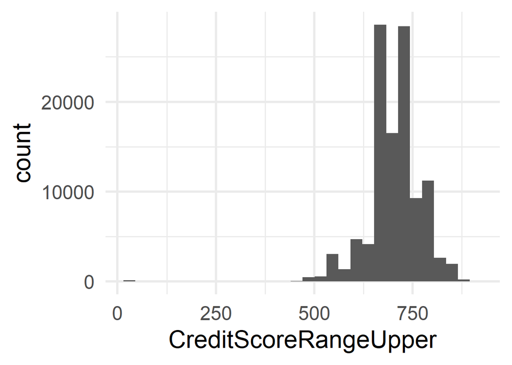

> Both lower and upper credit score ranges follow a general normal distribution. Both have dips in their peak regions though.

# Univariate Analysis

### What is/are the main feature(s) of interest in your dataset?

> The non-categorical variables appear follow normal or Poisson distributions. Most findings seem resonable, such as most loans being current, more populous states having greater portion of loans, most recipients being employed, middle income ranges for most recipients, and credit scores that are fairly good around 700.

> I think it would be interesting to further compare upper and lower credit scores. Side by side box plots can make the comparison more visible, while comparing the standard deviations of the 2 can provide more quantifiable comparison.

### Did you create any new variables from existing variables in the dataset?

> Listing category was originally had the awkward name “ProsperLoan$ListingCategory..numeric.” I reassigned that to the new variable ListingCategory. The IncomeRange variable was also re-ordered.

### Of the features you investigated, were there any unusual distributions?

Did you perform any operations on the data to tidy, adjust, or change the form  
of the data? If so, why did you do this?

> The listing category variable had a numeric key, so I used the description in the Variable Definitions document to create a descriptive factor varaible for this array. The x-axis variables did not appear in a very legible form, so for many plots I had to adjust the format using the ggplot theme layer.

> By adjusting the binwidth the peaks observed in the credit score distributions become irrelevant. However, there is still an increase in number of loans for lower credit scores that drops off before increasing again.

### Lower Credit Score Range (adjusted binwidth = 10)

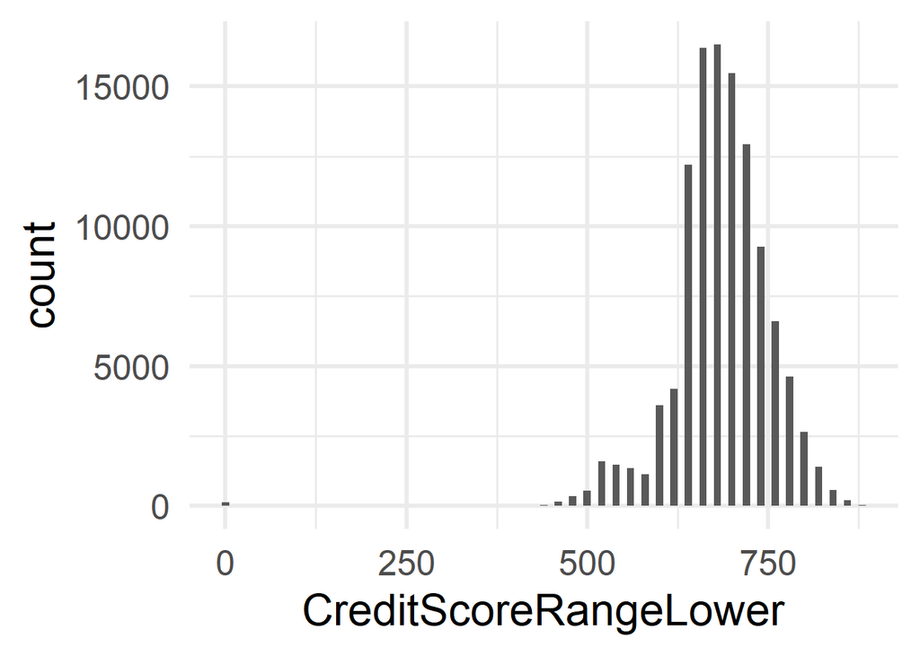

### Upper Credit Score Range (adjusted binwidth = 10)

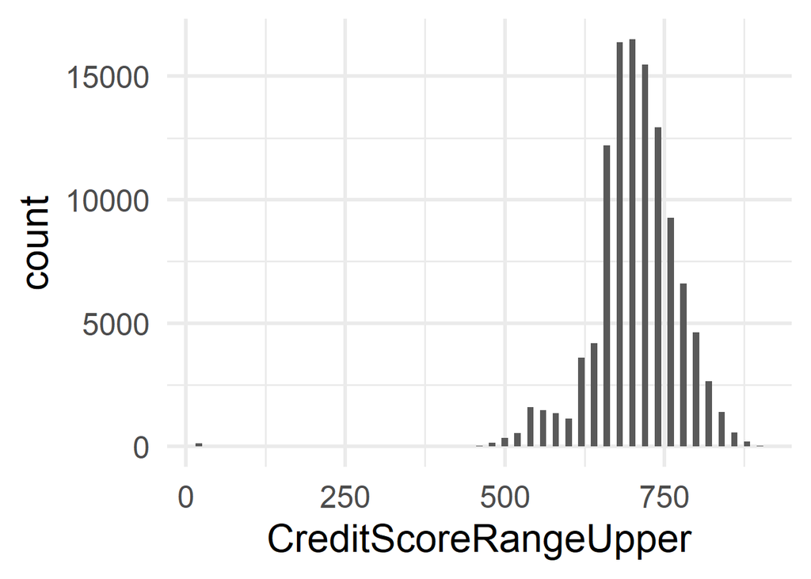

# Bivariate Plots Section

> Debt to Inome Ratio vs. Upper Credit Score Range

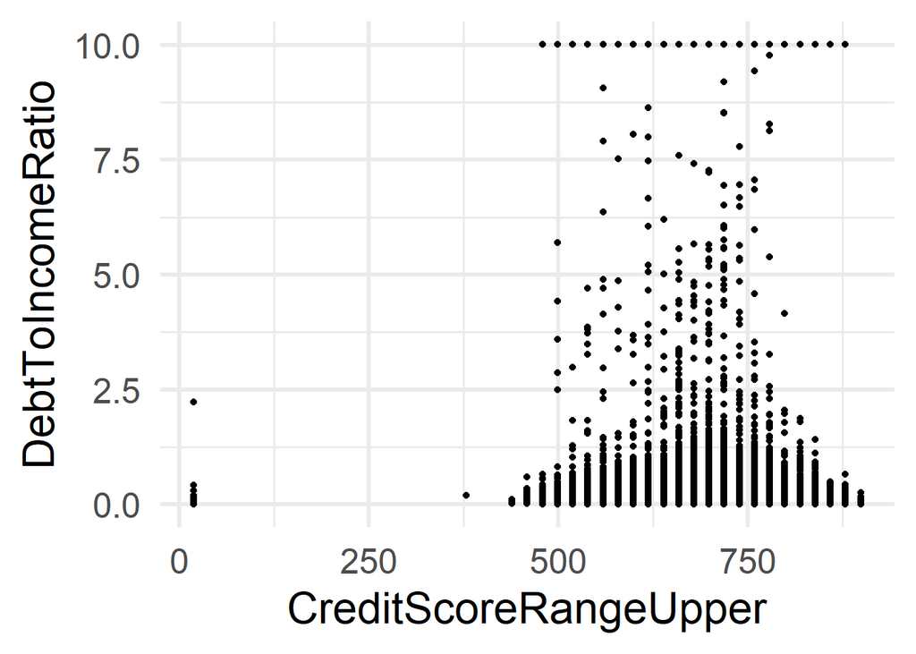

> Debt to Inome Ratio vs. Lower Credit Score Range

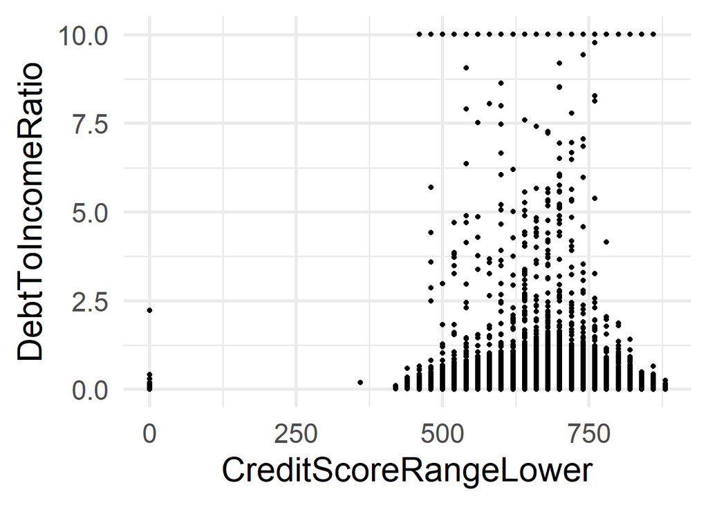

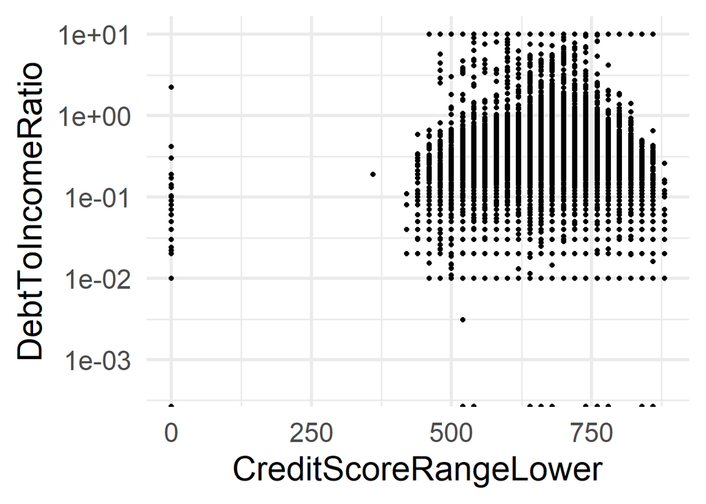

```
##
##  Pearson's product-moment correlation
##
## data:  loan$CreditScoreRangeLower and log(loan$DebtToIncomeRatio + 1)
## t = -0.7235, df = 104796, p-value = 0.4694
## alternative hypothesis: true correlation is not equal to 0
## 95 percent confidence interval:
##  -0.008289246  0.003819533
## sample estimates:
##          cor
## -0.002234938
```

> With an r of -0.002 there is hardly a correlation.

> Plotting mean of upper credit score range vs. DTI

```
## # A tibble: 6 x 3
##   DebtToIncomeRatio CreditScoreRangeUpper_mean     n
##               <dbl>                      <dbl> <int>
## 1           0                             685.    19
## 2           0.00044                        NA      1
## 3           0.0031                        539      1
## 4           0.00611                        NA      1
## 5           0.00647                        NA      1
## 6           0.00677                        NA      1
```

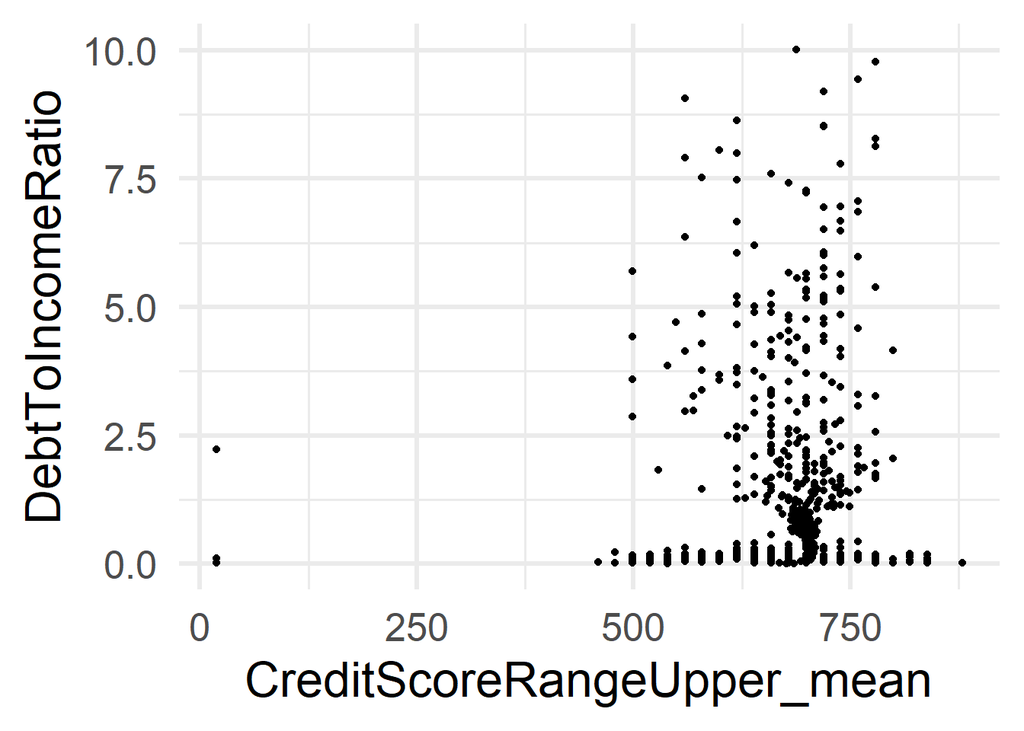

```
##
##  Pearson's product-moment correlation
##
## data:  log(loan.crsc_by_dti$CreditScoreRangeUpper_mean) and loan.crsc_by_dti$DebtToIncomeRatio
## t = 1.9022, df = 623, p-value = 0.05761
## alternative hypothesis: true correlation is not equal to 0
## 95 percent confidence interval:
##  -0.002451367  0.153500471
## sample estimates:
##        cor
## 0.07598925
```

> Even when using the mean of the Upper Credit Score Ranges there still isn’t much of a correlation with an r value of 0.08.

> Plotting mean of upper credit score range vs. log of DTI

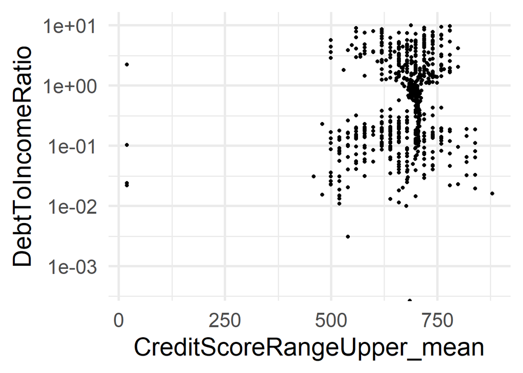

```
##
##  Pearson's product-moment correlation
##
## data:  loan.crsc_by_dti$CreditScoreRangeUpper_mean and log(loan.crsc_by_dti$DebtToIncomeRatio + 1)
## t = 3.7907, df = 623, p-value = 0.0001649
## alternative hypothesis: true correlation is not equal to 0
## 95 percent confidence interval:
##  0.07257642 0.22591357
## sample estimates:
##       cor
## 0.1501478
```

> With an r value of 0.15 there still isn’t a good correlation between the log of DTI and mean upper credit score.

> I thought there might be a relationship between credit score and debt to income ratio, but there doesn’t seem to be. Plotting the log of DTI doesn’t seem to change that much, although the correlation coefficient is higher but still not very good. Plotting the average upper credit score range vs. DTI did not lead to better results. The outlier in DTI is noticable, as are higher concentrations of lower DTIs.

> Dropping Not employed and not displayed categories from IncomeRange in order to plot only numeric ranges.

```r
loan$IncomeRangeNum <- ordered(loan$IncomeRange, levels = c('$0', '$1-24,999', '$25,000-49,999',                                                                      '$50,000-74,999', '$75,000-99,999',                                                                        '$100,000+'))
```

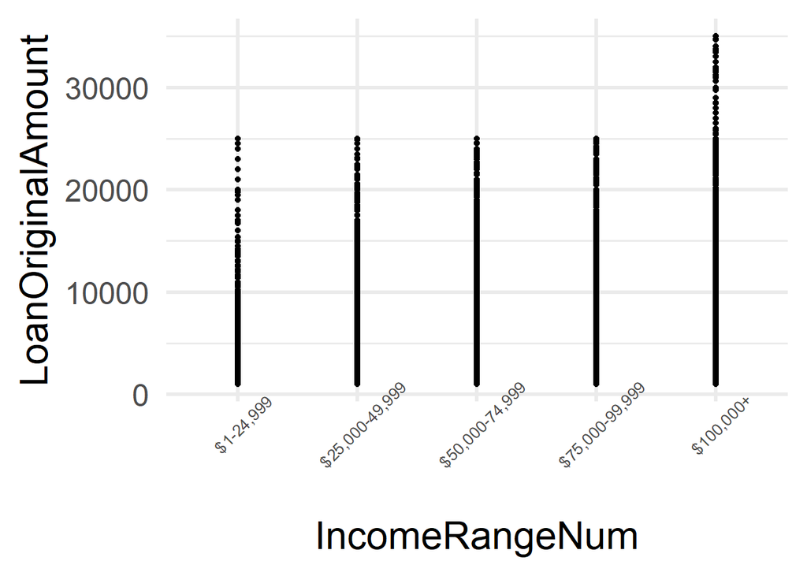

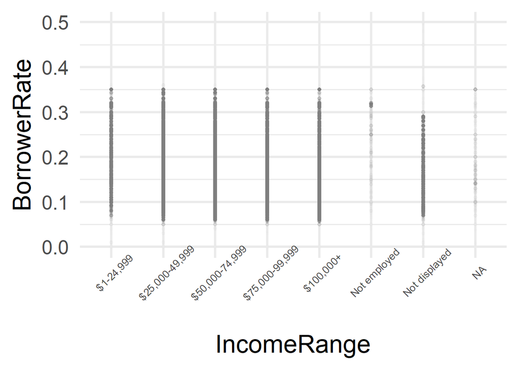

> There doesn’t appear to be much of a trend when comparing income range to borrower rate, even when plotting only 0.5% of the original data points.

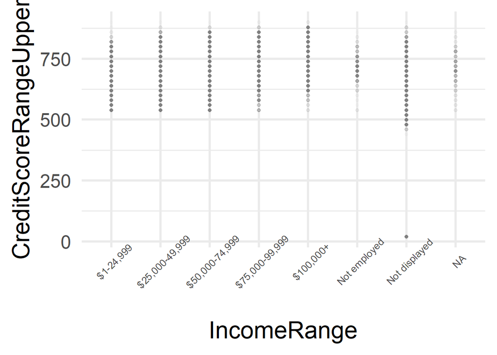

> By limiting the concentration of points plotted there does seem to be a slight increase in credit score as income rises.

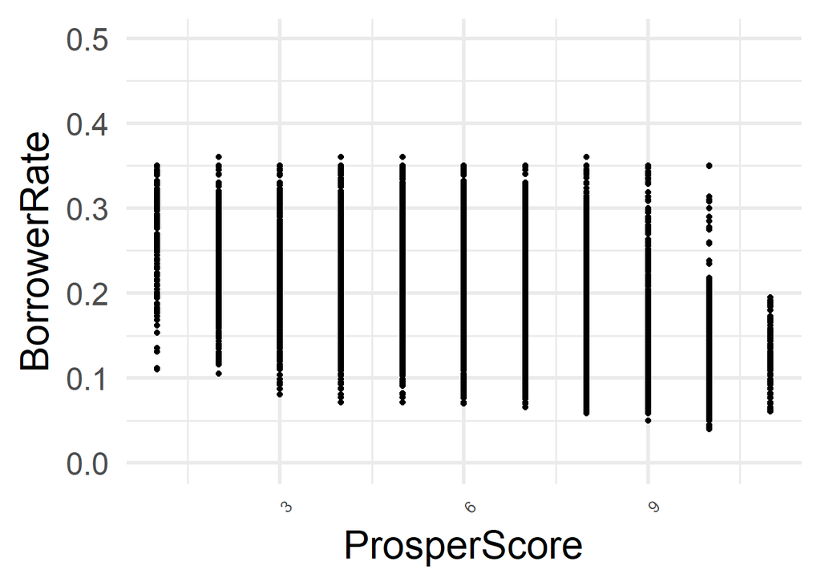

```
##
##  Pearson's product-moment correlation
##
## data:  loan$ProsperScore and loan$BorrowerRate
## t = -248.98, df = 84851, p-value < 2.2e-16
## alternative hypothesis: true correlation is not equal to 0
## 95 percent confidence interval:
##  -0.6536072 -0.6458311
## sample estimates:
##        cor
## -0.6497361
```

> There does seem to be a relationship between Prosper Score and borrower rate. The lower the Prosper Score the higher the borrower rate is. However there is only an r correlation coefficient of -0.65 which isn’t very strong.

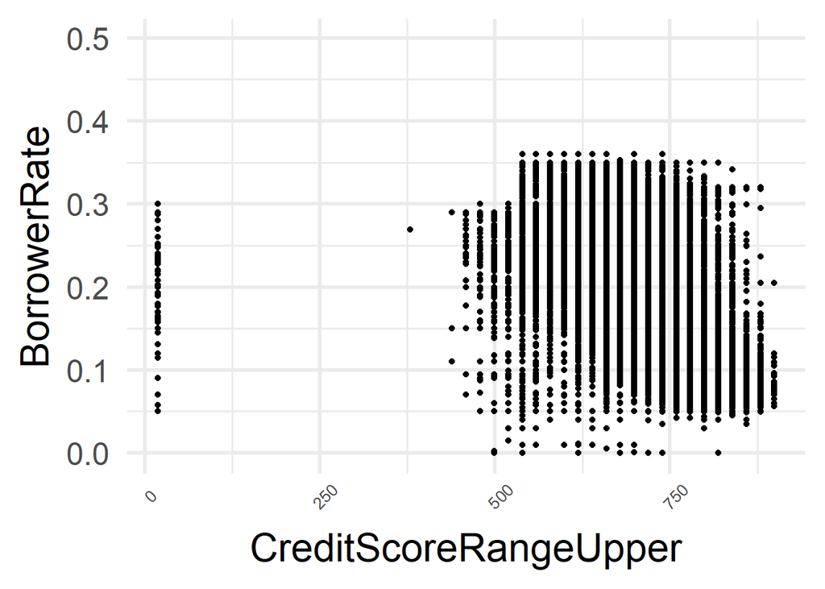

> There appears to be somewhat of a trend for lower borrower rates for higher credit scores. I wander if those outliers with near 0 upper credit scores obtained thier rates using some other factor in the Prosper Score.

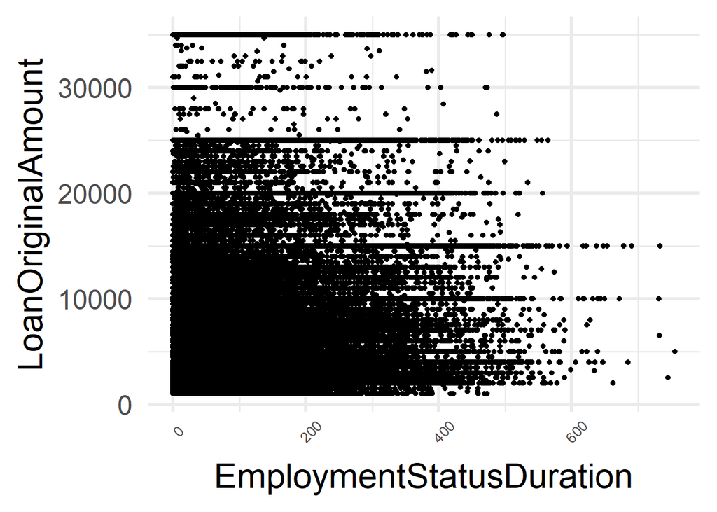

```
##
##  Pearson's product-moment correlation
##
## data:  loan$EmploymentStatusDuration and loan$LoanOriginalAmount
## t = 32.157, df = 106310, p-value < 2.2e-16
## alternative hypothesis: true correlation is not equal to 0
## 95 percent confidence interval:
##  0.09219259 0.10409908
## sample estimates:
##        cor
## 0.09814935
```

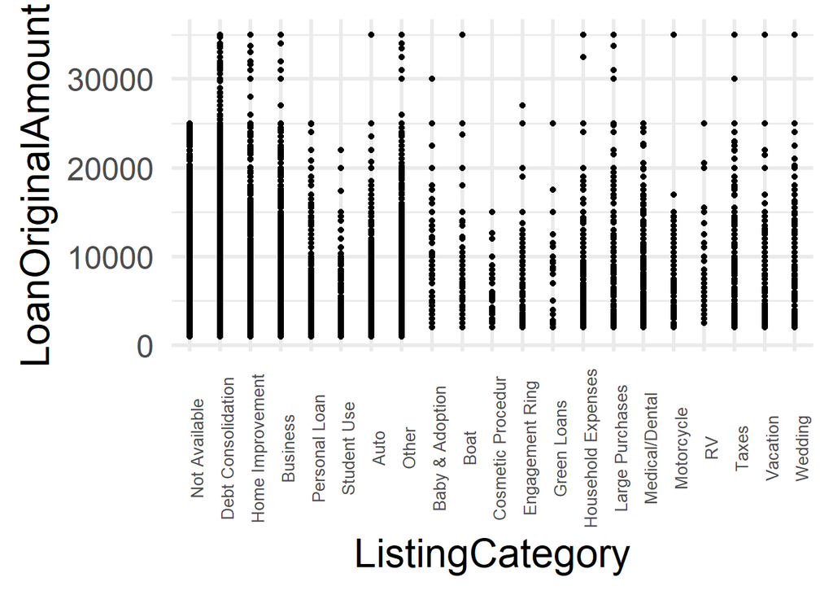

> Debt consolidation loans occur more frequently in higher amounts than others, while those for cosmetic procedures occur in lower amounts than other types.